# Diabetes Example

Mladen Kolar (mkolar@chicagobooth.edu)

We are going to investigate diabetes data from the [LARS paper](https://projecteuclid.org/euclid.aos/1083178935).

These data consist of observations on 442 patients, with the response of interest being a quantitative measure of disease progression one year after baseline.

There are ten baseline variables—age, sex, body-mass index, average blood pressure, and six blood serum measurements.

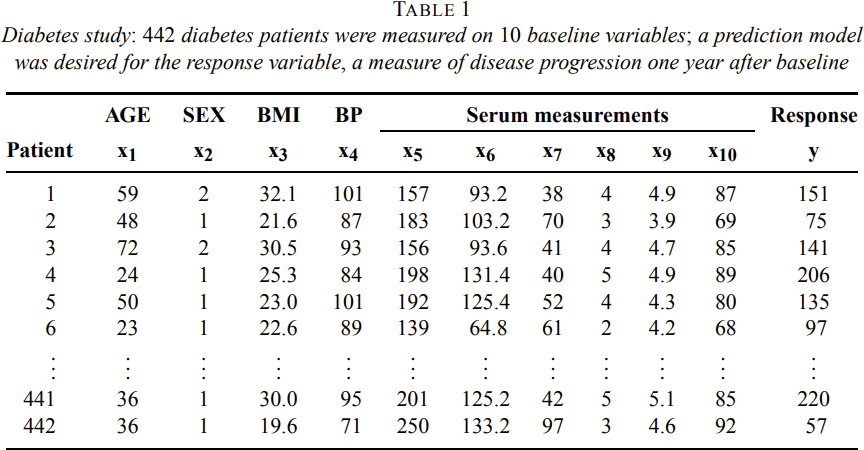

The goal is to construct a model that predicted response $y$ from covariates $x_1, x_2, \ldots, x_{10}$.

- the model would produce accurate baseline predictions of response for future patients;
- the form of the model would suggest which covariates were important factors in disease progression.

```r
df = read.csv('data.diabetes.csv')
```

Note that the covariates are standardized to have zero mean and unit L2 norm.

There are also data with interaction terms (the “quadratic model”). Here are the standardized data that have 442 rows and 65 columns corresponding to 64 input features and the output y.

```r
df.x2 = read.csv('data.diabetes.x2.csv')
```

# Subset Selection

We will use the package `bestglm` for an implementation of best subset selection in generalized linear models. See http://www2.uaem.mx/r-mirror/web/packages/bestglm/vignettes/bestglm.pdf for more details.

```r
library(bestglm)

set.seed(1)
```

Structure of the diabetes data

```r
str(df)
```

```
## 'data.frame':    442 obs. of  11 variables:
##  $ age: num  0.03808 -0.00188 0.0853 -0.08906 0.00538 ...
##  $ sex: num  0.0507 -0.0446 0.0507 -0.0446 -0.0446 ...
##  $ bmi: num  0.0617 -0.0515 0.0445 -0.0116 -0.0364 ...
##  $ map: num  0.02187 -0.02633 -0.00567 -0.03666 0.02187 ...
##  $ tc : num  -0.04422 -0.00845 -0.0456 0.01219 0.00393 ...
##  $ ldl: num  -0.0348 -0.0192 -0.0342 0.025 0.0156 ...
##  $ hdl: num  -0.0434 0.07441 -0.03236 -0.03604 0.00814 ...
##  $ tch: num  -0.00259 -0.03949 -0.00259 0.03431 -0.00259 ...
##  $ ltg: num  0.01991 -0.06833 0.00286 0.02269 -0.03199 ...
##  $ glu: num  -0.01765 -0.0922 -0.02593 -0.00936 -0.04664 ...
##  $ y  : int  151 75 141 206 135 97 138 63 110 310 ...
```

Plots the correlations among all the columns of data.

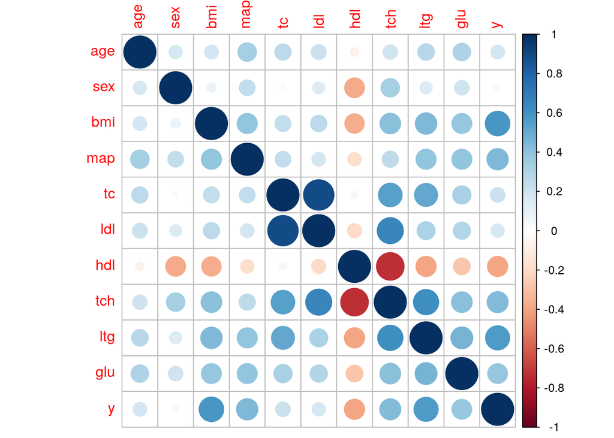

```r
library(corrplot)
correlations <- cor(df)
corrplot(correlations)
```

It is always a good idea to check for gross outliers:

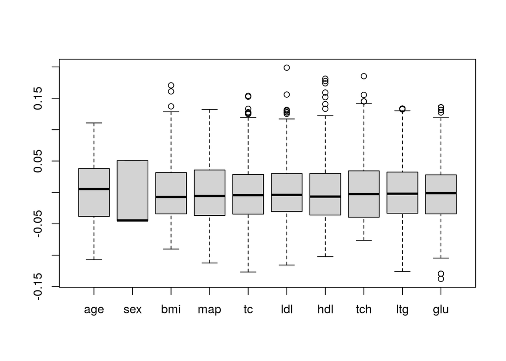

```r
boxplot(df[, -11])
```

## Best Subset Selection

The first 6 rows of our data frame.

```r
head(df)
```

```
##           age        sex        bmi         map          tc        ldl         hdl         tch         ltg         glu   y
## 1  0.03807591  0.0506801  0.0616962  0.02187235 -0.04422350 -0.0348208 -0.04340085 -0.00259226  0.01990842 -0.01764613 151
## 2 -0.00188202 -0.0446416 -0.0514741 -0.02632783 -0.00844872 -0.0191633  0.07441156 -0.03949338 -0.06832974 -0.09220405  75
## 3  0.08529891  0.0506801  0.0444512 -0.00567061 -0.04559945 -0.0341945 -0.03235593 -0.00259226  0.00286377 -0.02593034 141
## 4 -0.08906294 -0.0446416 -0.0115950 -0.03665645  0.01219057  0.0249906 -0.03603757  0.03430886  0.02269202 -0.00936191 206
## 5  0.00538306 -0.0446416 -0.0363847  0.02187235  0.00393485  0.0155961  0.00814208 -0.00259226 -0.03199144 -0.04664087 135
## 6 -0.09269548 -0.0446416 -0.0406959 -0.01944209 -0.06899065 -0.0792878  0.04127682 -0.07639450 -0.04118039 -0.09634616  97
```

We use best subset regression together with BIC to choose the model.

```r
best.subset.model.bic = bestglm(df, family = gaussian, IC = "BIC",
    method = "exhaustive")
best.subset.model.bic
```

```
## BIC
## BICq equivalent for q in (0.0393515029213214, 0.553673540299091)
## Best Model:
##             Estimate Std. Error  t value     Pr(>|t|)
## (Intercept)  152.133    2.58513 58.84935 1.51997e-209
## sex         -235.776   60.46916 -3.89911  1.11759e-04
## bmi          523.562   65.29360  8.01859  9.93614e-15
## map          326.236   63.08366  5.17148  3.54683e-07
## hdl         -289.117   65.64545 -4.40422  1.33742e-05
## ltg          474.292   65.68339  7.22088  2.31668e-12
```

The model has 5 variables.

We can see which variable were included at different stages.

```r
best.subset.model.bic$Subsets
```

```
##     (Intercept)   age   sex   bmi   map    tc   ldl   hdl   tch   ltg   glu logLikelihood     BIC
## 0          TRUE FALSE FALSE FALSE FALSE FALSE FALSE FALSE FALSE FALSE FALSE      -1919.99 3839.99
## 1          TRUE FALSE FALSE  TRUE FALSE FALSE FALSE FALSE FALSE FALSE FALSE      -1826.85 3659.79
## 2          TRUE FALSE FALSE  TRUE FALSE FALSE FALSE FALSE FALSE  TRUE FALSE      -1784.03 3580.24
## 3          TRUE FALSE FALSE  TRUE  TRUE FALSE FALSE FALSE FALSE  TRUE FALSE      -1775.44 3569.16
## 4          TRUE FALSE FALSE  TRUE  TRUE  TRUE FALSE FALSE FALSE  TRUE FALSE      -1770.31 3564.99
## 5*         TRUE FALSE  TRUE  TRUE  TRUE FALSE FALSE  TRUE FALSE  TRUE FALSE      -1762.96 3556.38
## 6          TRUE FALSE  TRUE  TRUE  TRUE  TRUE  TRUE FALSE FALSE  TRUE FALSE      -1760.13 3556.81
## 7          TRUE FALSE  TRUE  TRUE  TRUE  TRUE  TRUE FALSE  TRUE  TRUE FALSE      -1759.49 3561.62
## 8          TRUE FALSE  TRUE  TRUE  TRUE  TRUE  TRUE FALSE  TRUE  TRUE  TRUE      -1758.95 3566.63
## 9          TRUE FALSE  TRUE  TRUE  TRUE  TRUE  TRUE  TRUE  TRUE  TRUE  TRUE      -1758.84 3572.49
## 10         TRUE  TRUE  TRUE  TRUE  TRUE  TRUE  TRUE  TRUE  TRUE  TRUE  TRUE      -1758.82 3578.56
```

The last two columns report `logLikelihood` and `BIC`.  
The `logLikelihood` is computed on the training data. The higher is better.  
Notice that `logLikelihood` increases as we add more variables to our model.

The deviance for the model is equal to $-2 \cdot {\rm logLikelihood}$. The lower is better.  
`BIC` is equal to ${\rm deviance} + \log(n) \cdot k$ where $k$ is the number selected variables.

We can compute `BIC` from `logLikelihood`.  
We see that the numbers agree with the last column of the table above.

```r
n = nrow(df)
-2 * best.subset.model.bic$Subsets$logLikelihood + (0:10) * log(n)
```

```
##  [1] 3839.99 3659.79 3580.24 3569.16 3564.99 3556.38 3556.81 3561.62 3566.63 3572.49 3578.56
```

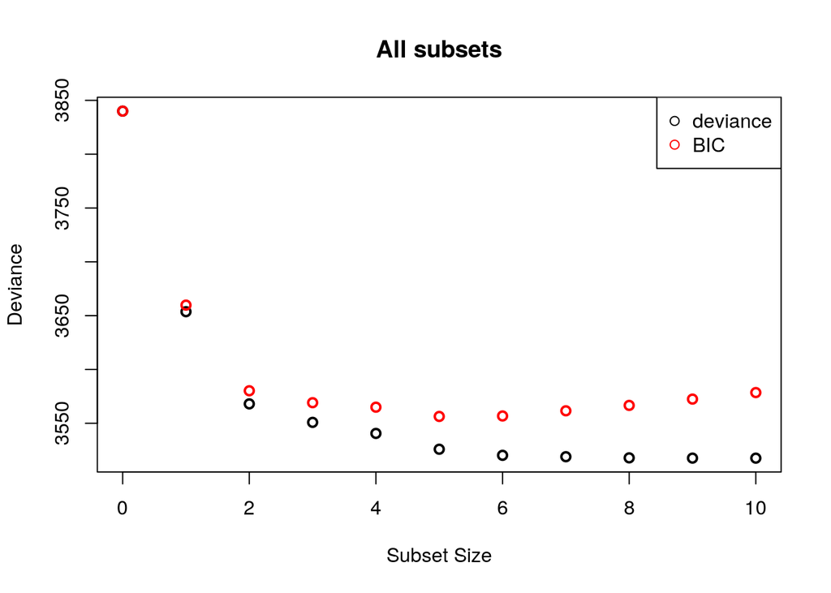

```r
dev.plot = -2 * best.subset.model.bic$Subsets$logLikelihood
bic.plot = best.subset.model.bic$Subsets$BIC
plot(0:10, dev.plot, lwd = 2, col = "black", type = "p", ylim = c(min(dev.plot),
    max(bic.plot)), xlab = "Subset Size", ylab = "Deviance",
    main = "All subsets")
points(0:10, bic.plot, lwd = 2, col = "red")
legend("topright", legend = c("deviance", "BIC"), col = c("black",
    "red"), pch = 1)
```

Let us now choose the model with cross-validation.

```r
best.subset.model.cv = bestglm(df, family = gaussian, IC = "CV",
    CVArgs = list(Method = "HTF", K = 10, REP = 1), method = "exhaustive")
best.subset.model.cv
```

```
## CV(K = 10, REP = 1)
## BICq equivalent for q in (0.00390833780440203, 0.0393515029213171)
## Best Model:
##             Estimate Std. Error  t value     Pr(>|t|)
## (Intercept)  152.133     2.6531 57.34184 9.69178e-206
## bmi          603.074    64.6772  9.32437  5.55472e-19
## map          262.275    62.9620  4.16560  3.74192e-05
## ltg          543.872    64.6187  8.41664  5.55616e-16
```

We can see which variable were included at different stages.

```r
best.subset.model.cv$Subsets
```

```
##     (Intercept)   age   sex   bmi   map    tc   ldl   hdl   tch   ltg   glu logLikelihood      CV    sdCV
## 0          TRUE FALSE FALSE FALSE FALSE FALSE FALSE FALSE FALSE FALSE FALSE      -1919.99 5947.31 214.298
## 1          TRUE FALSE FALSE  TRUE FALSE FALSE FALSE FALSE FALSE FALSE FALSE      -1826.85 3926.56 237.377
## 2          TRUE FALSE FALSE  TRUE FALSE FALSE FALSE FALSE FALSE  TRUE FALSE      -1784.03 3253.82 216.140
## 3*         TRUE FALSE FALSE  TRUE  TRUE FALSE FALSE FALSE FALSE  TRUE FALSE      -1775.44 3147.95 181.333
## 4          TRUE FALSE FALSE  TRUE  TRUE  TRUE FALSE FALSE FALSE  TRUE FALSE      -1770.31 3068.36 211.930
## 5          TRUE FALSE  TRUE  TRUE  TRUE FALSE FALSE  TRUE FALSE  TRUE FALSE      -1762.96 2990.59 246.220
## 6          TRUE FALSE  TRUE  TRUE  TRUE  TRUE  TRUE FALSE FALSE  TRUE FALSE      -1760.13 3000.74 147.167
## 7          TRUE FALSE  TRUE  TRUE  TRUE  TRUE  TRUE FALSE  TRUE  TRUE FALSE      -1759.49 2987.05 185.165
## 8          TRUE FALSE  TRUE  TRUE  TRUE  TRUE  TRUE FALSE  TRUE  TRUE  TRUE      -1758.95 2997.09 180.661
## 9          TRUE FALSE  TRUE  TRUE  TRUE  TRUE  TRUE  TRUE  TRUE  TRUE  TRUE      -1758.84 3027.52 256.020
## 10         TRUE  TRUE  TRUE  TRUE  TRUE  TRUE  TRUE  TRUE  TRUE  TRUE  TRUE      -1758.82 3017.61 132.170
```

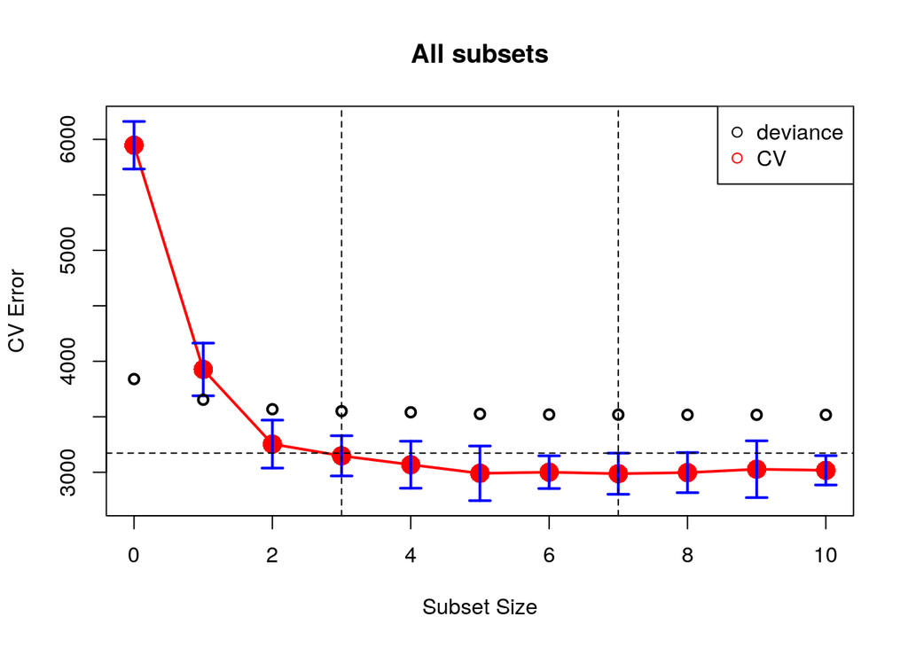

```r
dev.plot = -2 * best.subset.model.cv$Subsets$logLikelihood
cverrs = best.subset.model.cv$Subsets$CV
sdCV = best.subset.model.cv$Subsets$sdCV
CVLo = cverrs - sdCV
CVHi = cverrs + sdCV
k = 0:(length(cverrs) - 1)
plot(k, cverrs, xlab = "Subset Size", ylab = "CV Error", main = "All subsets",
    ylim = c(min(CVLo), max(CVHi)), type = "n")
points(k, cverrs, cex = 2, col = "red", pch = 16)
lines(k, cverrs, col = "red", lwd = 2)
# plot error bars
segments(k, CVLo, k, CVHi, col = "blue", lwd = 2)
eps = 0.15
segments(k - eps, CVLo, k + eps, CVLo, col = "blue", lwd = 2)
segments(k - eps, CVHi, k + eps, CVHi, col = "blue", lwd = 2)

indBest = oneSDRule(best.subset.model.cv$Subsets[, c("CV", "sdCV")])
abline(v = indBest - 1, lty = 2)
indMin = which.min(cverrs)
fmin = sdCV[indMin]
cutOff = fmin + cverrs[indMin]
abline(h = cutOff, lty = 2)
indMin = which.min(cverrs)
abline(v = indMin - 1, lty = 2)

points(0:10, dev.plot, lwd = 2, col = "black")
legend("topright", legend = c("deviance", "CV"), col = c("black",
    "red"), pch = 1)
```

We can compare the selected models using the `modelsummary` package:

```r
library(modelsummary)
msummary(list(BIC = best.subset.model.bic$BestModel, CV = best.subset.model.cv$BestModel))
```

|  | BIC | CV |
| --- | --- | --- |
| (Intercept) | 152.133 | 152.133 |
|  | (2.585) | (2.653) |
| sex | -235.776 |  |
|  | (60.469) |  |
| bmi | 523.562 | 603.074 |
|  | (65.294) | (64.677) |
| map | 326.236 | 262.275 |
|  | (63.084) | (62.962) |
| hdl | -289.117 |  |
|  | (65.645) |  |
| ltg | 474.292 | 543.872 |
|  | (65.683) | (64.619) |
| Num.Obs. | 442 | 442 |
| R2 | 0.509 | 0.480 |
| R2 Adj. | 0.503 | 0.477 |
| AIC | 4794.3 | 4815.2 |
| BIC | 4822.9 | 4835.7 |
| Log.Lik. | -2390.131 | -2402.613 |
| F | 90.264 | 134.814 |

# Forward Selection

```r
fwd.step.bic = bestglm(df, family = gaussian, IC = "BIC", method = "forward")
fwd.step.bic
```

```
## BIC
## BICq equivalent for q in (0.114626254149048, 0.917133329172765)
## Best Model:
##             Estimate Std. Error  t value     Pr(>|t|)
## (Intercept)  152.133    2.57159 59.15942 3.82489e-210
## sex         -226.511   59.85663 -3.78422  1.75803e-04
## bmi          529.873   65.62035  8.07483  6.69290e-15
## map          327.220   62.69319  5.21938  2.78580e-07
## tc          -757.938  160.43505 -4.72427  3.12197e-06
## ldl          538.586  146.73798  3.67039  2.72264e-04
## ltg          804.192   80.17314 10.03069  1.93785e-21
```

```r
fwd.step.bic$Subsets
```

```
##     (Intercept)   age   sex   bmi   map    tc   ldl   hdl   tch   ltg   glu logLikelihood     BIC
## 0          TRUE FALSE FALSE FALSE FALSE FALSE FALSE FALSE FALSE FALSE FALSE      -1919.99 3839.99
## 1          TRUE FALSE FALSE  TRUE FALSE FALSE FALSE FALSE FALSE FALSE FALSE      -1826.85 3659.79
## 2          TRUE FALSE FALSE  TRUE FALSE FALSE FALSE FALSE FALSE  TRUE FALSE      -1784.03 3580.24
## 3          TRUE FALSE FALSE  TRUE  TRUE FALSE FALSE FALSE FALSE  TRUE FALSE      -1775.44 3569.16
## 4          TRUE FALSE FALSE  TRUE  TRUE  TRUE FALSE FALSE FALSE  TRUE FALSE      -1770.31 3564.99
## 5          TRUE FALSE  TRUE  TRUE  TRUE  TRUE FALSE FALSE FALSE  TRUE FALSE      -1766.87 3564.20
## 6*         TRUE FALSE  TRUE  TRUE  TRUE  TRUE  TRUE FALSE FALSE  TRUE FALSE      -1760.13 3556.81
## 7          TRUE FALSE  TRUE  TRUE  TRUE  TRUE  TRUE FALSE  TRUE  TRUE FALSE      -1759.49 3561.62
## 8          TRUE FALSE  TRUE  TRUE  TRUE  TRUE  TRUE FALSE  TRUE  TRUE  TRUE      -1758.95 3566.63
## 9          TRUE FALSE  TRUE  TRUE  TRUE  TRUE  TRUE  TRUE  TRUE  TRUE  TRUE      -1758.84 3572.49
## 10         TRUE  TRUE  TRUE  TRUE  TRUE  TRUE  TRUE  TRUE  TRUE  TRUE  TRUE      -1758.82 3578.56
```

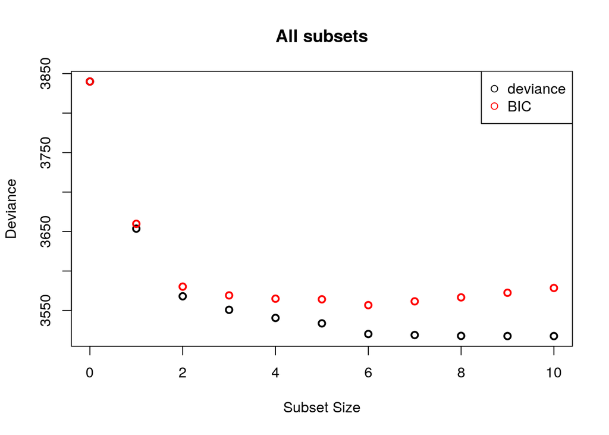

```r
dev.plot = -2 * fwd.step.bic$Subsets$logLikelihood
bic.plot = fwd.step.bic$Subsets$BIC
plot(0:10, dev.plot, lwd = 2, col = "black", type = "p", ylim = c(min(dev.plot),
    max(bic.plot)), xlab = "Subset Size", ylab = "Deviance",
    main = "All subsets")
points(0:10, bic.plot, lwd = 2, col = "red")
legend("topright", legend = c("deviance", "BIC"), col = c("black",
    "red"), pch = 1)
```

```r
fwd.step.cv = bestglm(df, family = gaussian, IC = "CV", CVArgs = list(Method = "HTF",
    K = 10, REP = 1), method = "forward")
fwd.step.cv
```

```
## CV(K = 10, REP = 1)
## BICq equivalent for q in (0.00390833780440114, 0.110469115613193)
## Best Model:
##             Estimate Std. Error  t value     Pr(>|t|)
## (Intercept)  152.133     2.6531 57.34184 9.69178e-206
## bmi          603.074    64.6772  9.32437  5.55472e-19
## map          262.275    62.9620  4.16560  3.74192e-05
## ltg          543.872    64.6187  8.41664  5.55616e-16
```

```r
fwd.step.cv$Subsets
```

```
##     (Intercept)   age   sex   bmi   map    tc   ldl   hdl   tch   ltg   glu logLikelihood      CV    sdCV
## 0          TRUE FALSE FALSE FALSE FALSE FALSE FALSE FALSE FALSE FALSE FALSE      -1919.99 5952.97 241.515
## 1          TRUE FALSE FALSE  TRUE FALSE FALSE FALSE FALSE FALSE FALSE FALSE      -1826.85 3911.11 258.034
## 2          TRUE FALSE FALSE  TRUE FALSE FALSE FALSE FALSE FALSE  TRUE FALSE      -1784.03 3245.10 196.562
## 3*         TRUE FALSE FALSE  TRUE  TRUE FALSE FALSE FALSE FALSE  TRUE FALSE      -1775.44 3141.29 131.031
## 4          TRUE FALSE FALSE  TRUE  TRUE  TRUE FALSE FALSE FALSE  TRUE FALSE      -1770.31 3073.64 147.410
## 5          TRUE FALSE  TRUE  TRUE  TRUE  TRUE FALSE FALSE FALSE  TRUE FALSE      -1766.87 3039.88 135.546
## 6          TRUE FALSE  TRUE  TRUE  TRUE  TRUE  TRUE FALSE FALSE  TRUE FALSE      -1760.13 2995.01 172.271
## 7          TRUE FALSE  TRUE  TRUE  TRUE  TRUE  TRUE FALSE  TRUE  TRUE FALSE      -1759.49 2984.37 186.390
## 8          TRUE FALSE  TRUE  TRUE  TRUE  TRUE  TRUE FALSE  TRUE  TRUE  TRUE      -1758.95 2998.36 173.390
## 9          TRUE FALSE  TRUE  TRUE  TRUE  TRUE  TRUE  TRUE  TRUE  TRUE  TRUE      -1758.84 2983.95 173.522
## 10         TRUE  TRUE  TRUE  TRUE  TRUE  TRUE  TRUE  TRUE  TRUE  TRUE  TRUE      -1758.82 3017.66 153.460
```

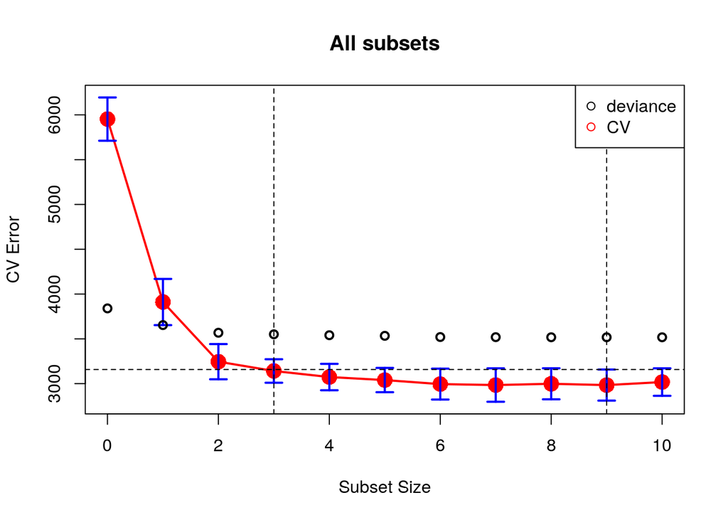

```r
dev.plot = -2 * fwd.step.cv$Subsets$logLikelihood
cverrs = fwd.step.cv$Subsets$CV
sdCV = fwd.step.cv$Subsets$sdCV
CVLo = cverrs - sdCV
CVHi = cverrs + sdCV
k = 0:(length(cverrs) - 1)
plot(k, cverrs, xlab = "Subset Size", ylab = "CV Error", main = "All subsets",
    ylim = c(min(CVLo), max(CVHi)), type = "n")
points(k, cverrs, cex = 2, col = "red", pch = 16)
lines(k, cverrs, col = "red", lwd = 2)
# plot error bars
segments(k, CVLo, k, CVHi, col = "blue", lwd = 2)
eps = 0.15
segments(k - eps, CVLo, k + eps, CVLo, col = "blue", lwd = 2)
segments(k - eps, CVHi, k + eps, CVHi, col = "blue", lwd = 2)

indBest = oneSDRule(fwd.step.cv$Subsets[, c("CV", "sdCV")])
abline(v = indBest - 1, lty = 2)
indMin = which.min(cverrs)
fmin = sdCV[indMin]
cutOff = fmin + cverrs[indMin]
abline(h = cutOff, lty = 2)
indMin = which.min(cverrs)
abline(v = indMin - 1, lty = 2)

points(0:10, dev.plot, lwd = 2, col = "black")
legend("topright", legend = c("deviance", "CV"), col = c("black",
    "red"), pch = 1)
```

## Backward selection

```r
bwd.step.bic = bestglm(df, family = gaussian, IC = "BIC", method = "backward")
bwd.step.bic
```

```
## BIC
## BICq equivalent for q in (0.114626254149048, 0.917133329172765)
## Best Model:
##             Estimate Std. Error  t value     Pr(>|t|)
## (Intercept)  152.133    2.57159 59.15942 3.82489e-210
## sex         -226.511   59.85663 -3.78422  1.75803e-04
## bmi          529.873   65.62035  8.07483  6.69290e-15
## map          327.220   62.69319  5.21938  2.78580e-07
## tc          -757.938  160.43505 -4.72427  3.12197e-06
## ldl          538.586  146.73798  3.67039  2.72264e-04
## ltg          804.192   80.17314 10.03069  1.93785e-21
```

```r
bwd.step.bic$Subsets
```

```
##     (Intercept)   age   sex   bmi   map    tc   ldl   hdl   tch   ltg   glu logLikelihood     BIC
## 0          TRUE FALSE FALSE FALSE FALSE FALSE FALSE FALSE FALSE FALSE FALSE      -1919.99 3839.99
## 1          TRUE FALSE FALSE  TRUE FALSE FALSE FALSE FALSE FALSE FALSE FALSE      -1826.85 3659.79
## 2          TRUE FALSE FALSE  TRUE FALSE FALSE FALSE FALSE FALSE  TRUE FALSE      -1784.03 3580.24
## 3          TRUE FALSE FALSE  TRUE  TRUE FALSE FALSE FALSE FALSE  TRUE FALSE      -1775.44 3569.16
## 4          TRUE FALSE FALSE  TRUE  TRUE  TRUE FALSE FALSE FALSE  TRUE FALSE      -1770.31 3564.99
## 5          TRUE FALSE  TRUE  TRUE  TRUE  TRUE FALSE FALSE FALSE  TRUE FALSE      -1766.87 3564.20
## 6*         TRUE FALSE  TRUE  TRUE  TRUE  TRUE  TRUE FALSE FALSE  TRUE FALSE      -1760.13 3556.81
## 7          TRUE FALSE  TRUE  TRUE  TRUE  TRUE  TRUE FALSE  TRUE  TRUE FALSE      -1759.49 3561.62
## 8          TRUE FALSE  TRUE  TRUE  TRUE  TRUE  TRUE FALSE  TRUE  TRUE  TRUE      -1758.95 3566.63
## 9          TRUE FALSE  TRUE  TRUE  TRUE  TRUE  TRUE  TRUE  TRUE  TRUE  TRUE      -1758.84 3572.49
## 10         TRUE  TRUE  TRUE  TRUE  TRUE  TRUE  TRUE  TRUE  TRUE  TRUE  TRUE      -1758.82 3578.56
```

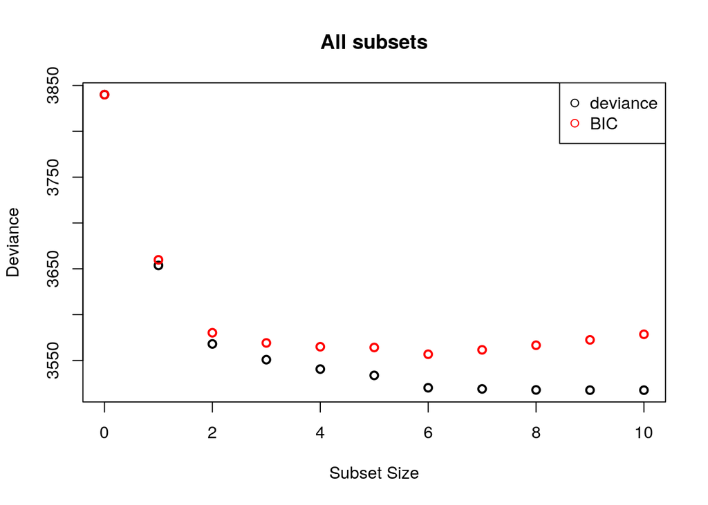

```r
dev.plot = -2 * bwd.step.bic$Subsets$logLikelihood
bic.plot = bwd.step.bic$Subsets$BIC
plot(0:10, dev.plot, lwd = 2, col = "black", type = "p", ylim = c(min(dev.plot),
    max(bic.plot)), xlab = "Subset Size", ylab = "Deviance",
    main = "All subsets")
points(0:10, bic.plot, lwd = 2, col = "red")
legend("topright", legend = c("deviance", "BIC"), col = c("black",
    "red"), pch = 1)
```

```r
bwd.step.cv = bestglm(df,
                      family = gaussian,
                      IC     = "CV",
                      CVArgs = list(Method="HTF", K=10, REP=1),
                      method = "backward")
bwd.step.cv
```

```
## CV(K = 10, REP = 1)
## BICq equivalent for q in (0.00390833780440114, 0.110469115613193)
## Best Model:
##             Estimate Std. Error  t value     Pr(>|t|)
## (Intercept)  152.133     2.6531 57.34184 9.69178e-206
## bmi          603.074    64.6772  9.32437  5.55472e-19
## map          262.275    62.9620  4.16560  3.74192e-05
## ltg          543.872    64.6187  8.41664  5.55616e-16
```

```r
bwd.step.cv$Subsets
```

```
##     (Intercept)   age   sex   bmi   map    tc   ldl   hdl   tch   ltg   glu logLikelihood      CV    sdCV
## 0          TRUE FALSE FALSE FALSE FALSE FALSE FALSE FALSE FALSE FALSE FALSE      -1919.99 5957.83 290.804
## 1          TRUE FALSE FALSE  TRUE FALSE FALSE FALSE FALSE FALSE FALSE FALSE      -1826.85 3917.74 254.498
## 2          TRUE FALSE FALSE  TRUE FALSE FALSE FALSE FALSE FALSE  TRUE FALSE      -1784.03 3247.63 143.447
## 3*         TRUE FALSE FALSE  TRUE  TRUE FALSE FALSE FALSE FALSE  TRUE FALSE      -1775.44 3168.59 203.177
## 4          TRUE FALSE FALSE  TRUE  TRUE  TRUE FALSE FALSE FALSE  TRUE FALSE      -1770.31 3116.16 165.834
## 5          TRUE FALSE  TRUE  TRUE  TRUE  TRUE FALSE FALSE FALSE  TRUE FALSE      -1766.87 3067.57 165.503
## 6          TRUE FALSE  TRUE  TRUE  TRUE  TRUE  TRUE FALSE FALSE  TRUE FALSE      -1760.13 2983.66 205.513
## 7          TRUE FALSE  TRUE  TRUE  TRUE  TRUE  TRUE FALSE  TRUE  TRUE FALSE      -1759.49 2985.83 176.468
## 8          TRUE FALSE  TRUE  TRUE  TRUE  TRUE  TRUE FALSE  TRUE  TRUE  TRUE      -1758.95 2977.99 265.406
## 9          TRUE FALSE  TRUE  TRUE  TRUE  TRUE  TRUE  TRUE  TRUE  TRUE  TRUE      -1758.84 3055.74 248.287
## 10         TRUE  TRUE  TRUE  TRUE  TRUE  TRUE  TRUE  TRUE  TRUE  TRUE  TRUE      -1758.82 3006.53 240.295
```

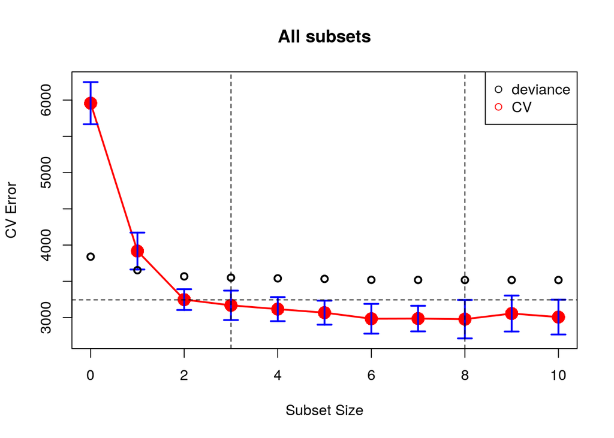

```r
dev.plot = -2 * bwd.step.cv$Subsets$logLikelihood
cverrs = bwd.step.cv$Subsets$CV
sdCV = bwd.step.cv$Subsets$sdCV
CVLo = cverrs - sdCV
CVHi = cverrs + sdCV
k = 0:(length(cverrs) - 1)
plot(k, cverrs, xlab = "Subset Size", ylab = "CV Error", main = "All subsets",
    ylim = c(min(CVLo), max(CVHi)), type = "n")
points(k, cverrs, cex = 2, col = "red", pch = 16)
lines(k, cverrs, col = "red", lwd = 2)
# plot error bars
segments(k, CVLo, k, CVHi, col = "blue", lwd = 2)
eps = 0.15
segments(k - eps, CVLo, k + eps, CVLo, col = "blue", lwd = 2)
segments(k - eps, CVHi, k + eps, CVHi, col = "blue", lwd = 2)

indBest = oneSDRule(bwd.step.cv$Subsets[, c("CV", "sdCV")])
abline(v = indBest - 1, lty = 2)
indMin = which.min(cverrs)
fmin = sdCV[indMin]
cutOff = fmin + cverrs[indMin]
abline(h = cutOff, lty = 2)
indMin = which.min(cverrs)
abline(v = indMin - 1, lty = 2)

points(0:10, dev.plot, lwd = 2, col = "black")
legend("topright", legend = c("deviance", "CV"), col = c("black",
    "red"), pch = 1)
```

```r
msummary(list(`BIC best subset` = best.subset.model.bic$BestModel,
    `CV best subset` = best.subset.model.cv$BestModel, `BIC Step fwd` = fwd.step.bic$BestModel,
    `CV Step fwd` = fwd.step.cv$BestModel, `BIC Step bwd` = bwd.step.bic$BestModel,
    `CV Step bwd` = bwd.step.cv$BestModel))
```

|  | BIC best subset | CV best subset | BIC Step fwd | CV Step fwd | BIC Step bwd | CV Step bwd |
| --- | --- | --- | --- | --- | --- | --- |
| (Intercept) | 152.133 | 152.133 | 152.133 | 152.133 | 152.133 | 152.133 |
|  | (2.585) | (2.653) | (2.572) | (2.653) | (2.572) | (2.653) |
| sex | -235.776 |  | -226.511 |  | -226.511 |  |
|  | (60.469) |  | (59.857) |  | (59.857) |  |
| bmi | 523.562 | 603.074 | 529.873 | 603.074 | 529.873 | 603.074 |
|  | (65.294) | (64.677) | (65.620) | (64.677) | (65.620) | (64.677) |
| map | 326.236 | 262.275 | 327.220 | 262.275 | 327.220 | 262.275 |
|  | (63.084) | (62.962) | (62.693) | (62.962) | (62.693) | (62.962) |
| hdl | -289.117 |  |  |  |  |  |
|  | (65.645) |  |  |  |  |  |
| ltg | 474.292 | 543.872 | 804.192 | 543.872 | 804.192 | 543.872 |
|  | (65.683) | (64.619) | (80.173) | (64.619) | (80.173) | (64.619) |
| tc |  |  | -757.938 |  | -757.938 |  |
|  |  |  | (160.435) |  | (160.435) |  |
| ldl |  |  | 538.586 |  | 538.586 |  |
|  |  |  | (146.738) |  | (146.738) |  |
| Num.Obs. | 442 | 442 | 442 | 442 | 442 | 442 |
| R2 | 0.509 | 0.480 | 0.515 | 0.480 | 0.515 | 0.480 |
| R2 Adj. | 0.503 | 0.477 | 0.508 | 0.477 | 0.508 | 0.477 |
| AIC | 4794.3 | 4815.2 | 4790.6 | 4815.2 | 4790.6 | 4815.2 |
| BIC | 4822.9 | 4835.7 | 4823.3 | 4835.7 | 4823.3 | 4835.7 |
| Log.Lik. | -2390.131 | -2402.613 | -2387.301 | -2402.613 | -2387.301 | -2402.613 |
| F | 90.264 | 134.814 | 76.949 | 134.814 | 76.949 | 134.814 |

# Shrinkage Procedures

The package `glmnet` implements Lasso and Ridge regression.

```r
library(glmnet)
```

## Lasso fit

Lasso regression with the `glmnet()` function has as a first argument the design matrix and as a second argument the response vector.

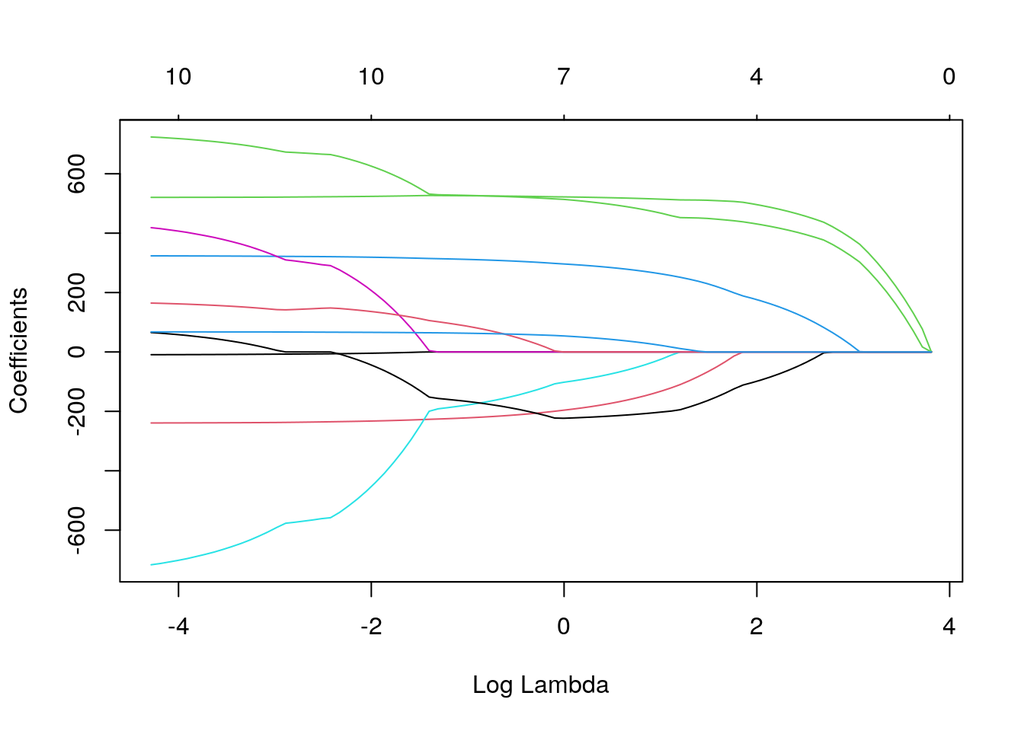

```r
x = as.matrix(df[, 1:10])
y = df[, 11]
lasso.fit = glmnet(x, y)
plot(lasso.fit, xvar = "lambda")
```

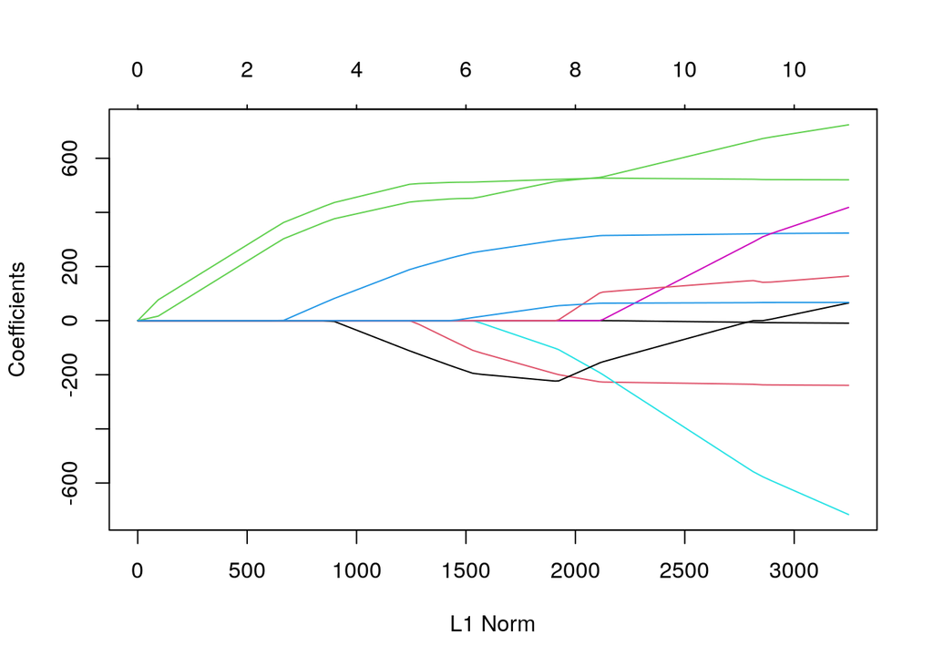

```r
plot(lasso.fit, xvar = "norm")
```

```r
data.frame(lasso = as.matrix(coef(lasso.fit, s = c(5, 1, 0.5))),
    LS = coef(lm(y ~ x)))
```

```
##               lasso.1   lasso.2   lasso.3        LS
## (Intercept)  152.1335  152.1335  152.1335  152.1335
## age            0.0000    0.0000    0.0000  -10.0122
## sex          -45.3307 -195.8991 -216.3709 -239.8191
## bmi          509.0521  522.0514  525.0789  519.8398
## map          217.2039  296.1883  308.3026  324.3904
## tc             0.0000 -101.8619 -160.9598 -792.1842
## ldl            0.0000    0.0000    0.0000  476.7458
## hdl         -147.7367 -223.2235 -180.4619  101.0446
## tch            0.0000    0.0000   66.1035  177.0642
## ltg          446.3482  513.5737  524.2176  751.2793
## glu            0.0000   53.8605   61.1546   67.6254
```

We observe that the lasso

- Can shrink coefficients exactly to zero
- Simultaneously estimates and selects coefficients

We need to choose lambda.

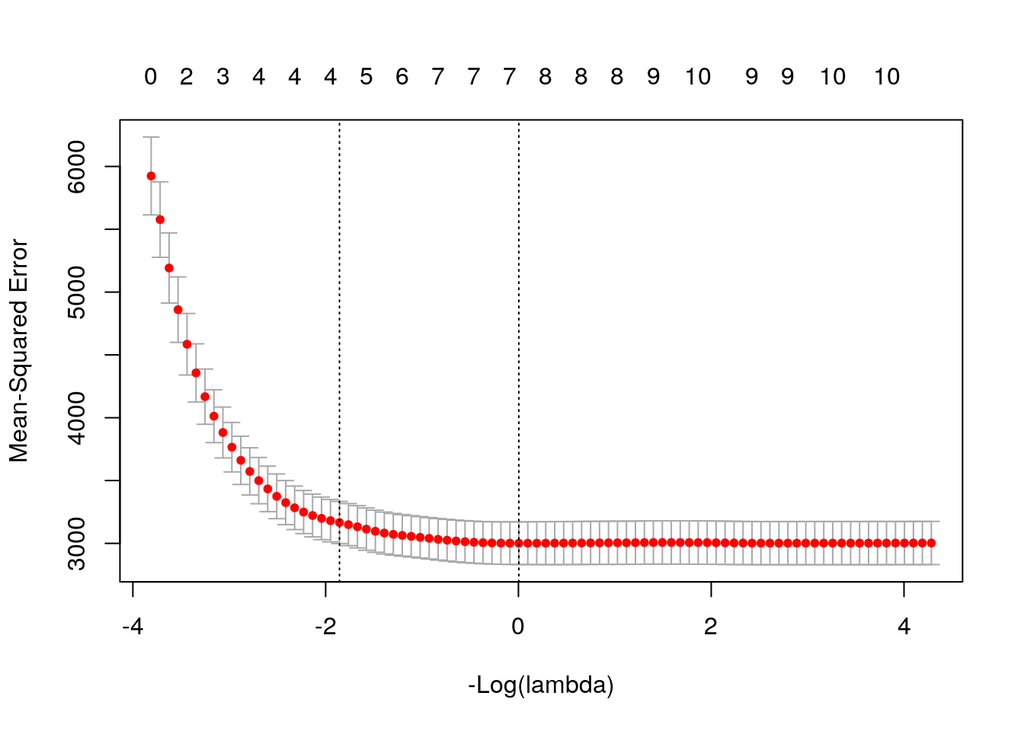

```r
lasso.cv = cv.glmnet(x, y)
plot(lasso.cv, sign.lambda = -1)
```

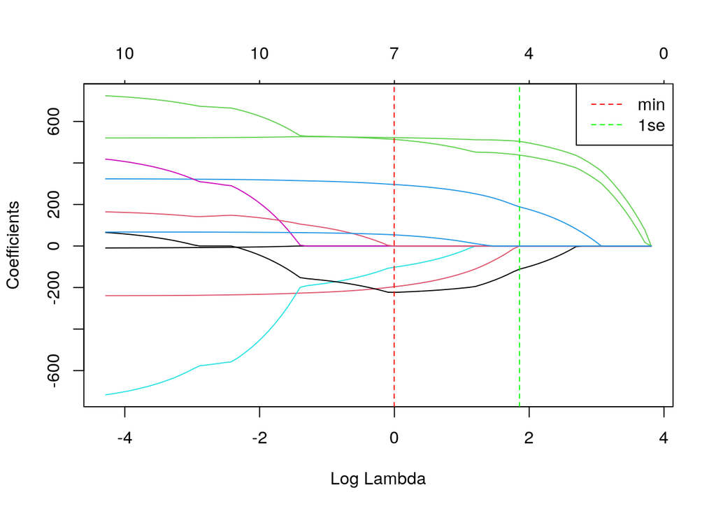

```r
glmnet.fit <- lasso.cv$glmnet.fit
plot(glmnet.fit, xvar = "lambda")
abline(v = log(lasso.cv$lambda.min), lty = 2, col = "red")
abline(v = log(lasso.cv$lambda.1se), lty = 2, col = "green")
legend("topright", legend = c("min", "1se"), lty = 2, col = c("red",
    "green"))
```

Let us investigate coefficients for these values of lambda:

```r
coef(lasso.cv, s = c(lasso.cv$lambda.min, lasso.cv$lambda.1se))
```

```
## 11 x 2 sparse Matrix of class "dgCMatrix"
##                     1        2
## (Intercept)  152.1335  152.133
## age            .         .
## sex         -196.0525    .
## bmi          522.0697  503.926
## map          296.2682  188.587
## tc          -102.0470    .
## ldl            .         .
## hdl         -223.2737 -111.373
## tch            .         .
## ltg          513.6844  438.132
## glu           53.9368    .
```

## Ridge regression fit

Ridge regression with the `glmnet()` function by changing one of its default options to `alpha=0`. By default, `alpha=1`, which results in a lasso fit.

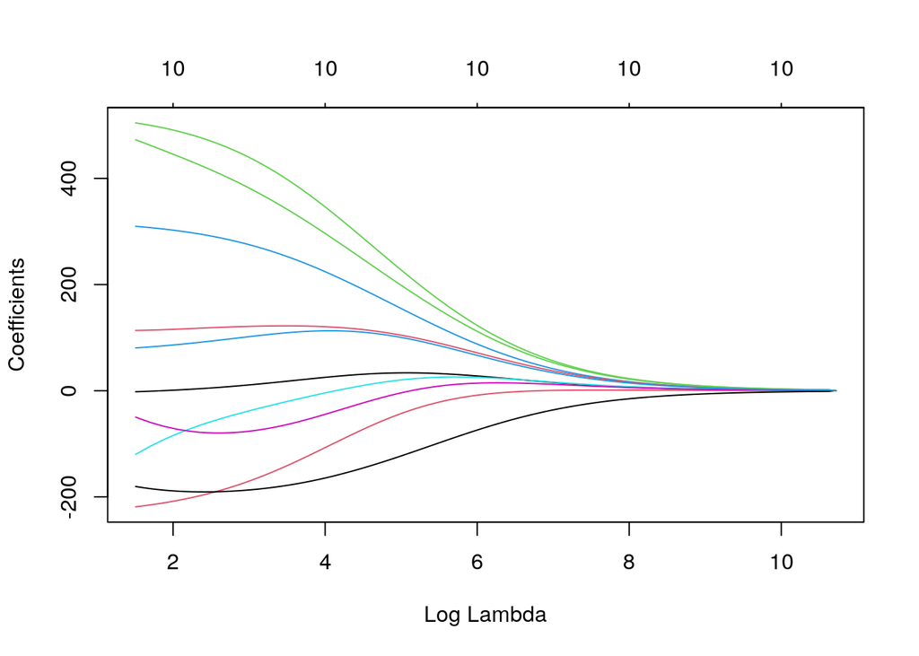

```r
ridge.fit = glmnet(x, y, alpha = 0)
plot(ridge.fit, xvar = "lambda")
```

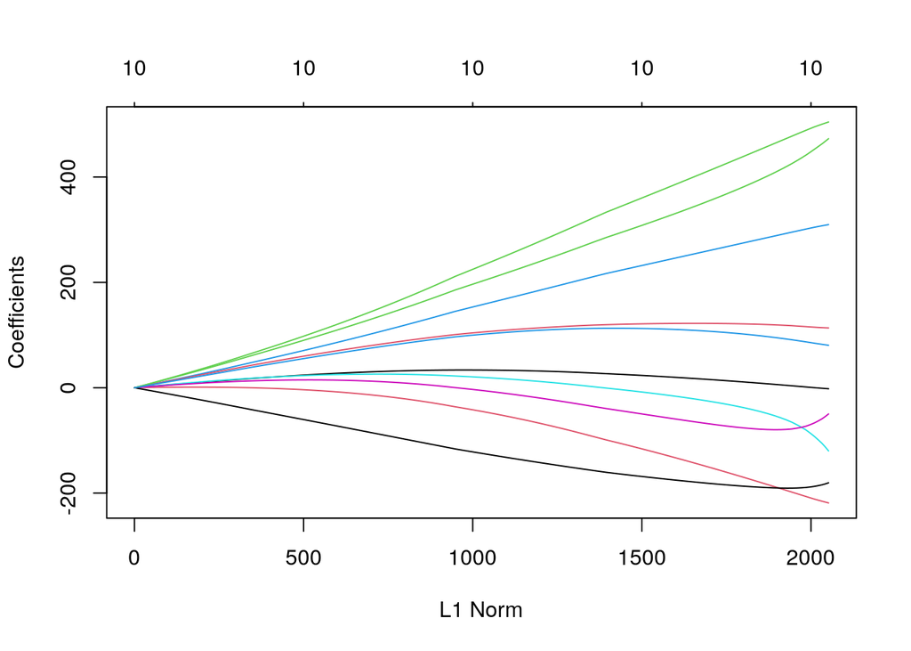

```r
plot(ridge.fit, xvar = "norm")
```

```r
data.frame(ridge = as.matrix(coef(ridge.fit, s = c(20, 5, 0.5))),
    LS = coef(lm(y ~ x)))
```

```
##               ridge.1    ridge.2    ridge.3        LS
## (Intercept)  152.1335  152.13348  152.13348  152.1335
## age           10.8902   -1.43612   -1.96337  -10.0122
## sex         -170.4771 -216.87920 -218.70102 -239.8191
## bmi          439.8970  502.19778  504.47617  519.8398
## map          275.3302  308.46252  309.70894  324.3904
## tc           -38.0885 -111.76126 -119.90721 -792.1842
## ldl          -76.3744  -55.04932  -49.70356  476.7458
## hdl         -186.9910 -182.69253 -180.45431  101.0446
## tch          121.2141  113.82106  113.54664  177.0642
## ltg          382.1315  467.33835  472.88600  751.2793
## glu          101.7900   81.62029   80.60826   67.6254
```

We observe that the ridge regression

- Estimates the values of the coefficients
- Does not shrink coefficients exactly to zero

We need to choose lambda.

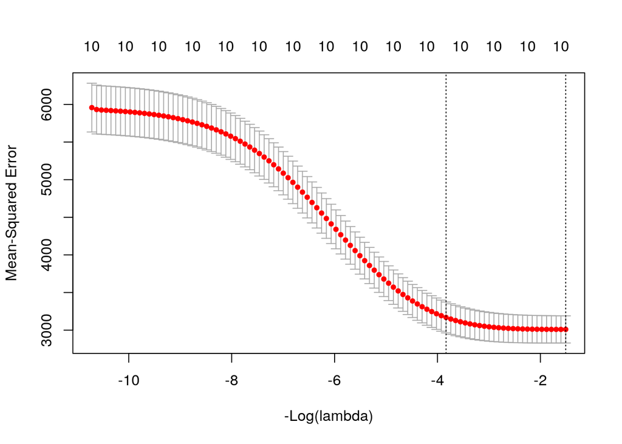

```r
ridge.cv = cv.glmnet(x, y, alpha = 0)
plot(ridge.cv, sign.lambda = -1)
```

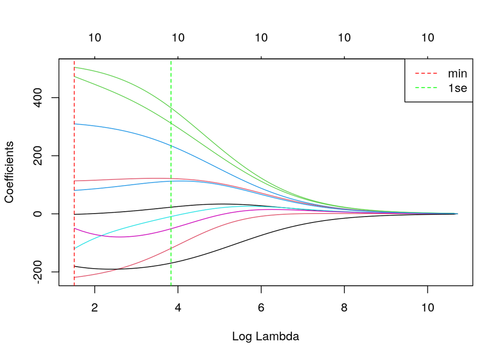

```r
glmnet.fit <- ridge.cv$glmnet.fit
plot(glmnet.fit, xvar = "lambda")
abline(v = log(ridge.cv$lambda.min), lty = 2, col = "red")
abline(v = log(ridge.cv$lambda.1se), lty = 2, col = "green")
legend("topright", legend = c("min", "1se"), lty = 2, col = c("red",
    "green"))
```

Let us investigate coefficients for these values of lambda:

```r
coef(ridge.cv, s = c(ridge.cv$lambda.min, ridge.cv$lambda.1se))
```

```
## 11 x 2 sparse Matrix of class "dgCMatrix"
##                      1          2
## (Intercept)  152.13348  152.13348
## age           -1.96337   22.84656
## sex         -218.70102 -118.75838
## bmi          504.47617  364.55610
## map          309.70894  234.40082
## tc          -119.90721   -9.34233
## ldl          -49.70356  -51.34324
## hdl         -180.45431 -169.65366
## tch          113.54664  121.50336
## ltg          472.88600  311.91195
## glu           80.60826  112.31675
```